# Chapter 8 – Linear Discriminant Analysis (LDA)

Historical Background

**Linear Discriminant Analysis (LDA)** was first introduced by **Ronald A. Fisher (1936)** as a statistical method for classifying observations into distinct categories. Fisher’s original work focused on **two-class problems**, demonstrating how linear combinations of variables could optimally separate different populations. Later, in **1948**, **C.R. Rao** extended Fisher’s approach to handle **multiple classes**, leading to what is now called **Multi-class Linear Discriminant Analysis (MLDA)** or **Multiple Discriminant Analysis (MDA)**.

Concept and Purpose

LDA is a **supervised learning** method that serves both as a **classification technique** and a **dimensionality reduction method**.

The main goal of LDA is to:

> **Project high-dimensional data onto a lower-dimensional subspace** that maximizes class separability — preserving differences between classes while minimizing variation within each class.

This projection enables:

- Better **class discrimination** for visualization and prediction.
- Reduced **computational cost** in lower-dimensional spaces.
- **Noise reduction**, since LDA focuses on the most discriminative directions.

Mathematical Foundation LDA finds projection directions $w$ that **maximize the ratio** of between-class to within-class variance:

$$ \hat{w} = \arg\max_{w} \frac{w^T S_b w}{w^T S_w w} $$

where

- $S_w$: *Within-class scatter matrix*
  $$ S_w = \sum_{k=1}^{K} \sum_{x_i \in C_k} (x_i - \mu_k)(x_i - \mu_k)^T $$
- $S_b$: *Between-class scatter matrix*
  $$ S_b = \sum_{k=1}^{K} n_k (\mu_k - \mu)(\mu_k - \mu)^T $$

with

- $\mu_k$: mean vector of class $k$
- $\mu$: overall mean vector
- $n_k$: number of observations in class $k$

The discriminant directions are obtained from the **eigenvectors of** $S_w^{-1} S_b$ associated with the largest eigenvalues. We adjust the angle so that: The shadows of different classes are as far apart as possible The shadows of points in the same class are as tight as possible We want a projection direction that: Stretches the space between classes Compresses the space within each class

Probabilistic Model and Decision Rule

Assume each class $k$ follows a **multivariate normal (Gaussian)** distribution:

$$ f_k(\mathbf{x}) = \frac{1}{(2\pi)^{p/2}|\Sigma_k|^{1/2}} \exp\left(-\frac{1}{2}(\mathbf{x}-\boldsymbol{\mu}_k)^\top \Sigma_k^{-1}(\mathbf{x}-\boldsymbol{\mu}_k)\right) $$

- **LDA assumption:** $\Sigma_k = \Sigma$ for all $k$
- **QDA assumption:** $\Sigma_k$ may differ across classes

Let $\pi_k$ denote the prior probability of class $k$.  
Then, the **discriminant function** for class $k$ is:

$$ \delta_k(\mathbf{x}) = \mathbf{x}^\top \Sigma^{-1}\boldsymbol{\mu}_k -\frac{1}{2}\boldsymbol{\mu}_k^\top\Sigma^{-1}\boldsymbol{\mu}_k +\log(\pi_k) $$

A new observation $\mathbf{x}$ is assigned to the class with the **highest discriminant score**:

$$ \widehat{f}(\mathbf{x}) = \arg\max_k \, \delta_k(\mathbf{x}) $$

Linear Decision Boundaries

For two classes $k$ and $l$, the decision boundary satisfies:

$$ \mathbf{x}^\top \mathbf{w}_k + b_k = \mathbf{x}^\top \mathbf{w}_l + b_l $$

Simplifying, we obtain the **linear boundary equation**:

$$ \mathbf{x}^\top (\mathbf{w}_k - \mathbf{w}_l) + (b_k - b_l) = 0 $$

This defines a **hyperplane** separating the classes.

- The **normal vector** $(\mathbf{w}_k - \mathbf{w}_l)$ determines the orientation.
- The **intercept** $(b_k - b_l)$ determines the offset.

### Assumptions

- Multivariate normality within each class
- Equal covariance matrices across classes
- Adequate sample size per class to estimate means/covariances

Extensions and Related Methods

- **Quadratic Discriminant Analysis (QDA):** Allows class-specific covariance matrices → quadratic boundaries.
- **Regularized Discriminant Analysis (RDA):** Shrinks class covariances toward a pooled or diagonal matrix for stability in small samples.
- **Kernel Discriminant Analysis:** Projects data into a higher-dimensional space to capture **nonlinear** class boundaries.

```
'data.frame':	150 obs. of  5 variables:
 $ Sepal.Length: num  5.1 4.9 4.7 4.6 5 5.4 4.6 5 4.4 4.9 ...
 $ Sepal.Width : num  3.5 3 3.2 3.1 3.6 3.9 3.4 3.4 2.9 3.1 ...
 $ Petal.Length: num  1.4 1.4 1.3 1.5 1.4 1.7 1.4 1.5 1.4 1.5 ...
 $ Petal.Width : num  0.2 0.2 0.2 0.2 0.2 0.4 0.3 0.2 0.2 0.1 ...
 $ Species     : Factor w/ 3 levels "setosa","versicolor",..: 1 1 1 1 1 1 1 1 1 1 ...
```

```
           Df    Wilks approx F num Df den Df    Pr(>F)
Species     2 0.023439   199.15      8    288 < 2.2e-16 ***
Residuals 147
---
Signif. codes:  0 ‘***’ 0.001 ‘**’ 0.01 ‘*’ 0.05 ‘.’ 0.1 ‘ ’ 1
```

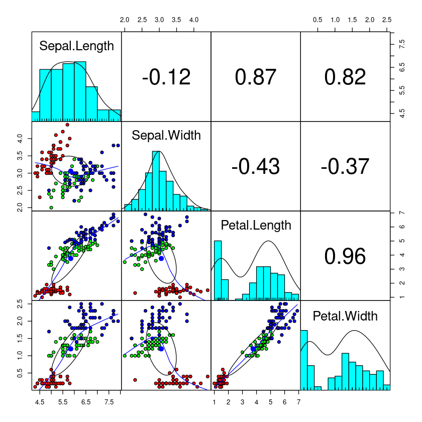

```r
#Example

library(klaR)
library(psych)
library(ggplot2)
data(iris)
str(iris)


#Data visulization.
#pairs(iris)

#p2 = ggplot(data= iris, aes(x = Sepal.Length , y = Sepal.Width, color = Species      ))+ geom_point()  +
#     geom_smooth(method = "lm")  + labs(y= "Sepal.Width", x = "Sepal.Length")

#p3 = ggplot(data= iris, aes(x = Petal.Length , y = Sepal.Width, color = Species      ))+ geom_point()  +
#     geom_smooth(method = "lm")  + labs(y= "Petal.Length", x = "Sepal.Length")

pairs.panels(iris[1:4],
             gap = 0,
             bg = c("red", "green", "blue")[iris$Species],
             pch = 21)

#It visually supports how Linear Discriminant Analysis (LDA) can separate the species based on linear combinations of these features.



#--------------------------------------------------------
# Suggestion: If MANOVA is not significant, LDA may not be useful
#--------------------------------------------------------
manova.fit = manova(cbind(Sepal.Length, Sepal.Width, Petal.Length, Petal.Width) ~ Species, data = iris)
summary(manova.fit, test = "Wilks")     # Check significance
```

```r
#Run LDA

#dat = iris
#dat[1:4] = scale(dat[1:4])

#Suggestion, if MANOVA is not significant, we may not need LDA

#Use dat instead of iris if to run LDA on standardized data
#Linear discriminant analysis in R
fit = lda(Species~., data = iris)
fit

#In the dataset,  the proportions are 0.33, 0.33 and 0.33 for  setosa, versicolor,  virginica
#The first Linear dicrimanant component is
# 0.8293776xSepal.Length + 1.5344731x Sepal.Width + -2.2012117x Petal.Length -2.8104603 x Petal.Width  (related to a direction)
```

```
Call:
lda(Species ~ ., data = iris)

Prior probabilities of groups:
    setosa versicolor  virginica
 0.3333333  0.3333333  0.3333333

Group means:
           Sepal.Length Sepal.Width Petal.Length Petal.Width
setosa            5.006       3.428        1.462       0.246
versicolor        5.936       2.770        4.260       1.326
virginica         6.588       2.974        5.552       2.026

Coefficients of linear discriminants:
                    LD1         LD2
Sepal.Length  0.8293776  0.02410215
Sepal.Width   1.5344731  2.16452123
Petal.Length -2.2012117 -0.93192121
Petal.Width  -2.8104603  2.83918785

Proportion of trace:
   LD1    LD2
0.9912 0.0088
```

Coefficients of linear discriminants There are 3 classes - LD1 , LD2 (2 linear transformations)

$LD1 = 0.8293776 \times Sepal.Length + 1.5344731 \times Sepal.Width + ... -2.8104603 \times Petal.Width $